# Statistical evidence in environmental and biological sciences: A comparison of P value and Bayes factor hypothesis testing

Yefeng Yang, Maximilian Maier, Malgorzata Lagisz, Shinichi Nakagawa

02-10-2025

# Set-up

Load necessary packages and custom functions. To fully reproduce the results presented in the main text, you will need to install all `R` packages listed below. Package information is present at the end of this website.

```r
suppressMessages({
  library(dplyr)
  library(readr)
  library(tidyr)
  library(tidyverse)
  library(stringr)
  library(ggplot2)
  library(metafor)
  library(here)
  library(ggExtra)
  library(boot)
  library(DescTools)
  library(BayesFactor)
  library(XICOR)
  library(irr)
  library(wesanderson)
  library(viridis)
  library(paletteer)
  library(ggsci)
  library(cowplot)
  library(patchwork)
  library(aplot)
  })

source(here("Func","func.R"))
```

# Load data

Thanks to the journals’ mandatory open data policies and the widespread adoption of FAIR (Findable, Accessible, Interoperable, Reusable) data sharing principles, there is a wealth of publicly available, well-organised data that can be reused for secondary analysis.

Our dataset comprise 23,164 experiments from two independent groups related to environmental science, ecology and evolutionary biology. We collated the dataset from publicly accessible meta-analytical datasets:

> Yang, Y. et al. Publication bias impacts on effect size, statistical power, and magnitude (Type M) and sign (Type S) errors in ecology and evolutionary biology. BMC Biology 21, 1-20 (2023).

> Senior, A. M. et al. Heterogeneity in ecological and evolutionary meta‐analyses: its magnitude and implications. Ecology 97, 3293-3299 (2016).

> Hillebrand, H. et al. Thresholds for ecological responses to global change do not emerge from empirical data. Nature Ecology & Evolution 4, 1502-1509 (2020).

Load the dataset and have some basic data wrangling:

```r
# load
## Yang_BMCBio_2023
dat_Yang_BMCBio_2023 <- readRDS(here("Dat","dat_Yang_BMCBio_2023_SMD.rds"))
## Yang_GCB_2022
dat_Yang_GCB_2022 <- readRDS(here("Dat","dat_Yang_GCB_2022_SMD.rds"))
## Senior_Ecology_2016
dat_Senior_Ecology_2016 <- readRDS(here("Dat","dat_Senior_Ecology_2016_SMD.rds"))

# combine all dat
## a function to rename
rename_and_select <- function(df, var_names) {
  df %>%
    rename(m1 = !!var_names[1],
           m2 = !!var_names[2],
           sd1 = !!var_names[3],
           sd2 = !!var_names[4],
           n1 = !!var_names[5],
           n2 = !!var_names[6])
}

## reate a new list to store the combined data
dat_list <- list()

## dat_Yang_BMCBio_2023
for(i in seq_along(dat_Yang_BMCBio_2023)) {
  dat_list[[paste0("BMCBio_", i)]] <- rename_and_select(
    dat_Yang_BMCBio_2023[[i]],
    c("T_mean", "C_mean", "T_sd", "C_sd", "T_n", "C_n")
  )
}

## dat_Yang_GCB_2022
for(i in seq_along(dat_Yang_GCB_2022)) {
  dat_list[[paste0("GCB_", i)]] <- rename_and_select(
    dat_Yang_GCB_2022[[i]],
    c("T_mean", "C_mean", "T_sd", "C_sd", "T_N", "C_N")
  )
}

## dat_Senior_Ecology_2016
for(i in seq_along(dat_Senior_Ecology_2016)) {
  dat_list[[paste0("Ecology_", i)]] <- rename_and_select(
    dat_Senior_Ecology_2016[[i]],
    c("mean_trt", "mean_ctrl", "SD_trt", "SD_ctrl", "N_trt", "N_ctrl")
  )
}

## only select relevant variables
dat_list <- lapply(dat_list, function(df) {
  df[, c("m1", "m2", "sd1", "sd2", "n1", "n2")]
})

# tidy data
dat <- do.call(rbind.data.frame, dat_list)
dat <- as.data.frame(dat)
knitr::kable(dfround(dat,3) %>% head(10), "pipe")
```

|  | m1 | m2 | sd1 | sd2 | n1 | n2 |
| --- | --- | --- | --- | --- | --- | --- |
| BMCBio_1.1 | 18.47 | 23.17 | 6.44 | 5.32 | 6 | 6 |
| BMCBio_1.2 | 5.87 | 6.56 | 2.24 | 3.22 | 14 | 14 |
| BMCBio_1.3 | 20.43 | 21.00 | 11.70 | 13.91 | 40 | 40 |
| BMCBio_1.4 | 2.56 | 3.97 | 0.95 | 1.52 | 10 | 10 |
| BMCBio_1.5 | 6.50 | 6.73 | 1.04 | 1.44 | 4 | 4 |
| BMCBio_1.6 | 68.40 | 54.00 | 5.13 | 10.08 | 9 | 9 |
| BMCBio_1.7 | 8.95 | 22.60 | 5.86 | 5.70 | 30 | 30 |
| BMCBio_1.8 | 16.35 | 11.00 | 11.04 | 7.27 | 10 | 10 |
| BMCBio_1.9 | 6.70 | 7.57 | 1.76 | 2.62 | 14 | 14 |
| BMCBio_1.10 | 6.78 | 6.08 | 5.90 | 3.93 | 23 | 23 |

# Estimation

We estimate statistical evidence based on classical (P values) and Bayesian (Bayes factors) hypothesis testing methods.

```r
# run the following code to get all metrics, which will take a long while; alternative, use the saved objects.
# create an empty result list
#res <- vector("list", nrow(dat))
# initialize the progress bar
#pb <- txtProgressBar(min = 1, max = nrow(dat), style = 3)
# computation
#for (i in 1:nrow(dat)) {
#  if (any(is.na(dat$m1[i]), is.na(dat$m2[i]), is.na(dat$sd1[i]), is.na(dat$sd2[i]), is.na(dat$n1[i]), is.na(dat$n2[i])) |
#      dat$n1[i] < 2 | dat$n2[i] < 2 | dat$sd1[i] <= 0 | dat$sd2[i] <= 0) {
#    res[[i]] <- NA
#  } else {
#    res[[i]] <- tryCatch({
#      calc_evi(m1 = dat$m1[i], m2 = dat$m2[i], sd1 = dat$sd1[i], sd2 = dat$sd2[i], n1 = dat$n1[i], n2 = dat$n2[i], rscale = sqrt(2) / 2)
#    }, error = function(e) {
#      NA  # assign NA if any error occurs during the calculation
#    })
#  }

  # update the progress bar
#  setTxtProgressBar(pb, i)
#}

# close the progress bar
#close(pb)

# convert it into a data frame
#res <- do.call(rbind.data.frame, res)

# bind
#dat <- cbind(dat, res)

#saveRDS(dat, here("Dat","dat0.707.rds"))
dat <- readRDS(here("Dat","dat0.707.rds"))
knitr::kable(dfround(dat,3) %>% head(10), "pipe")
```

|  | m1 | m2 | sd1 | sd2 | n1 | n2 | d | g | p | bf | pwr |
| --- | --- | --- | --- | --- | --- | --- | --- | --- | --- | --- | --- |
| BMCBio_1.1 | 18.47 | 23.17 | 6.44 | 5.32 | 6 | 6 | -0.796 | -0.735 | 0.198 | 8.300000e-01 | 0.239 |
| BMCBio_1.2 | 5.87 | 6.56 | 2.24 | 3.22 | 14 | 14 | -0.249 | -0.242 | 0.516 | 4.160000e-01 | 0.097 |
| BMCBio_1.3 | 20.43 | 21.00 | 11.70 | 13.91 | 40 | 40 | -0.044 | -0.044 | 0.843 | 2.360000e-01 | 0.054 |
| BMCBio_1.4 | 2.56 | 3.97 | 0.95 | 1.52 | 10 | 10 | -1.112 | -1.065 | 0.023 | 2.881000e+00 | 0.653 |
| BMCBio_1.5 | 6.50 | 6.73 | 1.04 | 1.44 | 4 | 4 | -0.183 | -0.159 | 0.804 | 5.340000e-01 | 0.056 |
| BMCBio_1.6 | 68.40 | 54.00 | 5.13 | 10.08 | 9 | 9 | 1.801 | 1.715 | 0.002 | 2.150400e+01 | 0.948 |
| BMCBio_1.7 | 8.95 | 22.60 | 5.86 | 5.70 | 30 | 30 | -2.361 | -2.331 | 0.000 | 6.886011e+09 | 1.000 |
| BMCBio_1.8 | 16.35 | 11.00 | 11.04 | 7.27 | 10 | 10 | 0.572 | 0.548 | 0.217 | 7.000000e-01 | 0.228 |
| BMCBio_1.9 | 6.70 | 7.57 | 1.76 | 2.62 | 14 | 14 | -0.390 | -0.378 | 0.312 | 5.250000e-01 | 0.169 |
| BMCBio_1.10 | 6.78 | 6.08 | 5.90 | 3.93 | 23 | 23 | 0.140 | 0.137 | 0.638 | 3.200000e-01 | 0.075 |

# Inter-rater agreement test

Calculate kappa coefficient to quantif the inter-rator agreement between classical (P values) and Bayesian (Bayes factors) hypothesis testing methods.

Data wrangling and baisc summary:

```r
# remove NA and inf
dat <- dat[!is.na(dat$bf) & is.finite(dat$bf), ]
# add effective sample size
dat <- dat %>% mutate(n = 4 * n1 * n2 / (n1 + n2))
# calculate posterior probability
dat <- dat %>% mutate(bf_post = bf / (1 + bf))

# add evidence label
dat <- dat %>% mutate(p_evi = case_when(p <= 0.05 ~ "True",
                                         p > 0.05 ~ "Null"),
                       bf_evi = case_when(bf >= 3 ~ "True",
                                          bf < 3 ~ "Null"))

# evidence category - presence of effect
table(dat$p_evi) # count(dat,bf_stren)
```

```
##
##  Null  True
## 12036  9347
```

```r
which(dat$p_evi == "True") %>% length() # 9347
```

```
## [1] 9347
```

```r
which(dat$p_evi == "Null") %>% length() # 12036
```

```
## [1] 12036
```

```r
which(dat$bf_evi == "True") %>% length() # 7970
```

```
## [1] 7970
```

```r
which(dat$bf_evi == "Null") %>% length() # 13413
```

```
## [1] 13413
```

Write a function to get bootstrapping Cohen’s Kappa and its 95% (percentile-based) confidence intervals.

Inter-rater agreement of evidence:

```r
# a function to calculate kappa from resampled data
kappa_stat <- function(data, indices) {
  # resample the data
  resampled_data <- data[indices, ]

  # calculate kappa statistic
  kappa_result <- kappa2(resampled_data, "unweighted")

  return(kappa_result$value)
}

# bootstrapping
set.seed(2024)  # for reproducibility
## run the following function, which will take a long while; alternatively load the pre-saved object
##kappa_evi <- boot(data = dat[, c("p_evi", "bf_evi")], statistic = kappa_stat, R = 25000)
#saveRDS(kappa_evi, here("Dat","kappa_evi_rscale0.7.rds"))
kappa_evi <- readRDS(here("Dat","kappa_evi_rscale0.7.rds"))

# check results
boot.ci(kappa_evi, type = "perc")
```

```
## BOOTSTRAP CONFIDENCE INTERVAL CALCULATIONS
## Based on 25000 bootstrap replicates
##
## CALL :
## boot.ci(boot.out = kappa_evi, type = "perc")
##
## Intervals :
## Level     Percentile
## 95%   ( 0.8601,  0.8736 )
## Calculations and Intervals on Original Scale
```

Inter-rater agreement of strength:

```r
# add strength label
dat <- dat %>%
  mutate(p_stren = case_when(
    p > 0.05 ~ "No or weak",
    p > 0.01 & p <= 0.05 ~ "Moderate or modest",
    p <= 0.01 ~ "Strong or very strong"
  ),
  bf_stren = case_when(
    bf < 3 ~ "No or weak",
    bf >= 3 & bf <= 10 ~ "Moderate or modest",
    bf > 10 ~ "Strong or very strong"
  ))
# bootstrapping
## run the following function; alternatively load the pre-saved object
## kappa_stren <- boot(data = dat[, c("p_stren", "bf_stren")],  statistic = kappa_stat, R = 25000)
#saveRDS(kappa_stren, here("Dat","kappa_stren_rscale0.7.rds"))
kappa_stren <- readRDS(here("Dat","kappa_stren_rscale0.7.rds"))

# results
boot.ci(kappa_stren, type = "perc")
```

```
## BOOTSTRAP CONFIDENCE INTERVAL CALCULATIONS
## Based on 25000 bootstrap replicates
##
## CALL :
## boot.ci(boot.out = kappa_stren, type = "perc")
##
## Intervals :
## Level     Percentile
## 95%   ( 0.7782,  0.7929 )
## Calculations and Intervals on Original Scale
```

# Correlation

Correlation tests between different statistical evidence metrics.

```r
# coefficient
cor.test(dat$p, (1 - dat$bf_post), method = "pearson")
```

```
##
##  Pearson's product-moment correlation
##
## data:  dat$p and (1 - dat$bf_post)
## t = 205.74, df = 21381, p-value < 2.2e-16
## alternative hypothesis: true correlation is not equal to 0
## 95 percent confidence interval:
##  0.8105636 0.8195609
## sample estimates:
##       cor
## 0.8151114
```

```r
calculateXI(dat$p, (1 - dat$bf_post))
```

```
## [1] 0.8746793
```

```r
d <- filter(dat,  bf_stren == "No or weak")
cor.test(d$p, (1 - d$bf_post), method = "pearson")
```

```
##
##  Pearson's product-moment correlation
##
## data:  d$p and (1 - d$bf_post)
## t = 158.12, df = 13411, p-value < 2.2e-16
## alternative hypothesis: true correlation is not equal to 0
## 95 percent confidence interval:
##  0.8007733 0.8125927
## sample estimates:
##       cor
## 0.8067637
```

```r
calculateXI(d$p, (1 - d$bf_post))
```

```
## [1] 0.6928194
```

```r
d <- filter(dat,  bf_stren == "Moderate or modest")
cor.test(d$p, (1 - d$bf_post), method = "pearson")
```

```
##
##  Pearson's product-moment correlation
##
## data:  d$p and (1 - d$bf_post)
## t = 203.72, df = 2251, p-value < 2.2e-16
## alternative hypothesis: true correlation is not equal to 0
## 95 percent confidence interval:
##  0.9717217 0.9759780
## sample estimates:
##       cor
## 0.9739354
```

```r
calculateXI(d$p, (1 - d$bf_post))
```

```
## [1] 0.910996
```

```r
d <- filter(dat,  bf_stren == "Strong or very strong")
cor.test(d$p, (1 - d$bf_post), method = "pearson")
```

```
##
##  Pearson's product-moment correlation
##
## data:  d$p and (1 - d$bf_post)
## t = 355.38, df = 5715, p-value < 2.2e-16
## alternative hypothesis: true correlation is not equal to 0
## 95 percent confidence interval:
##  0.9769635 0.9792094
## sample estimates:
##       cor
## 0.9781149
```

```r
calculateXI(d$p, (1 - d$bf_post))
```

```
## [1] 0.9610139
```

# Figure

The figures we reported in the main text.

## Figure 1

Visualize the inter-rater agreement of statistical evidence:

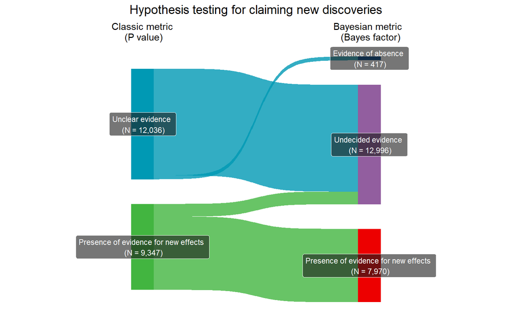

```r
# add evidence label
dat2 <- dat %>% mutate(p_evi = case_when(p <= 0.05 ~ "Presence of evidence for new effects",
                                         p > 0.05 ~ "Unclear evidence"),
                       bf_evi = case_when(bf >= 3 ~ "Presence of evidence for new effects",
                                          1/3 <= bf & bf < 3 ~ "Undecided evidence",
                                          bf < 1/3 ~ "Evidence of absence"))

# reformat
#tabyl(dat_fig,Frequentist, Bayesian)
dat_fig <- data.frame(evi = dat2$p_evi,
                      evi2 = dat2$bf_evi) %>%
  mutate(Frequentist = case_when(evi == "Presence of evidence for new effects" ~ "Presence of evidence for new effects \n (N = 9,347)",
                                 evi == "Unclear evidence" ~ "Unclear evidence \n (N = 12,036)"),
         Bayesian = case_when(evi2 == "Presence of evidence for new effects" ~ "Presence of evidence for new effects \n (N = 7,970)",
                              evi2 == "Evidence of absence" ~ "Evidence of absence \n (N = 417)",
                              evi2 == "Undecided evidence" ~ "Undecided evidence \n (N = 12,996)"))

datlong_fig <- dlong(dat_fig, Frequentist, Bayesian)
datlong_fig$node <- as.factor(datlong_fig$node)
datlong_fig$node <- factor(datlong_fig$node, levels = c("Presence of evidence for new effects \n (N = 9,347)", "Presence of evidence for new effects \n (N = 7,970)", "Undecided evidence \n (N = 12,996)", "Unclear evidence \n (N = 12,036)", "Evidence of absence \n (N = 417)"))

# plot
evidence.p <- ggplot(datlong_fig, aes(x = x, next_x = next_x, node = node, next_node = next_node, fill = factor(node), label = node)) +
  sankey_p(flow.alpha = 0.8, node.color = "transparent") +
  sankey_p_label(size = 3, color = "white", fill = "gray10", alpha = 0.6) +
  #scale_fill_manual(values = wes_palette("Cavalcanti1", n = 5)) +
  scale_fill_lancet() +
  theme_sankey(base_size = 10) +
  labs(x = NULL, title = "Hypothesis testing for claiming new discoveries") +
  theme(legend.position = "none",
        plot.title = element_text(color = "black", size = 14, hjust = .5),
        axis.text.x = element_text(color = "black", size = 11)) +
  scale_x_discrete(labels = c("Classic metric\n (P value)", "Bayesian metric \n (Bayes factor)"), position = "top")
evidence.p
```

Visualize the inter-rater agreement of strength:

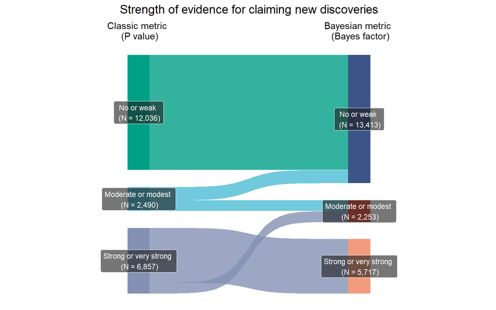

```r
# add strength label
dat2 <- dat %>%
  mutate(p_stren = case_when(
    p > 0.05 ~ "No or weak",
    p > 0.01 & p <= 0.05 ~ "Moderate or modest",
    p <= 0.01 ~ "Strong or very strong"
  ),
  bf_stren = case_when(
    bf < 3 ~ "No or weak",
    bf >= 3 & bf <= 10 ~ "Moderate or modest",
    bf > 10 ~ "Strong or very strong"
  ))

dat_fig <- data.frame(stren = dat2$p_stren,
                      stren2 = dat2$bf_stren) %>%
  mutate(Frequentist = case_when(stren == "No or weak" ~ "No or weak \n (N = 12,036)",
                                 stren == "Moderate or modest" ~ "Moderate or modest \n (N = 2,490)",
                                 stren == "Strong or very strong" ~ "Strong or very strong \n (N = 6,857)"),
         Bayesian = case_when(stren2 == "No or weak" ~ "No or weak \n (N = 13,413)",
                                 stren2 == "Moderate or modest" ~ "Moderate or modest \n (N = 2,253)",
                                 stren2 == "Strong or very strong" ~ "Strong or very strong \n (N = 5,717)"))


#tabyl(dat_fig,Frequentist, Bayesian)
datlong_fig <- dlong(dat_fig, Frequentist, Bayesian)
datlong_fig$node <- as.factor(datlong_fig$node)
datlong_fig$node <- factor(datlong_fig$node, levels = c("Strong or very strong \n (N = 5,717)", "Strong or very strong \n (N = 6,857)", "Moderate or modest \n (N = 2,253)", "Moderate or modest \n (N = 2,490)", "No or weak \n (N = 12,036)", "No or weak \n (N = 13,413)"))

# plot
strength.p <- ggplot(datlong_fig, aes(x = x, next_x = next_x, node = node, next_node = next_node, fill = factor(node), label = node)) +
  sankey_p(flow.alpha = 0.8, node.color = "transparent") +
  sankey_p_label(size = 3, color = "white", fill = "gray10", alpha = 0.6) +
  #scale_fill_manual(values = paletteer_d("nationalparkcolors::Acadia", n = 6)) +
  scale_fill_npg() +
  theme_sankey(base_size = 10) +
  labs(x = NULL, title = "Strength of evidence for claiming new discoveries") +
  theme(legend.position = "none",
        plot.title = element_text(color = "black", size = 14, hjust = .5),
        axis.text.x = element_text(color = "black", size = 11)) +
  scale_x_discrete(labels = c("Classic metric \n (P value)", "Bayesian metric \n (Bayes factor)"), position = "top")



# save
#png(filename = "./Fig/fig 1.png", width = 5, height = 8, units = "in", type = "windows", res = 600)
#evidence.p + strength.p + plot_layout(nrow = 2, ncol = 1 , tag_level = 'new') +
#  plot_annotation(tag_levels = list(c('A', "B"))) & theme(plot.tag = element_text(size = 12, face = "bold"))
#dev.off()
strength.p
```

## Figure 2

Visualize the correlation between different metrics:

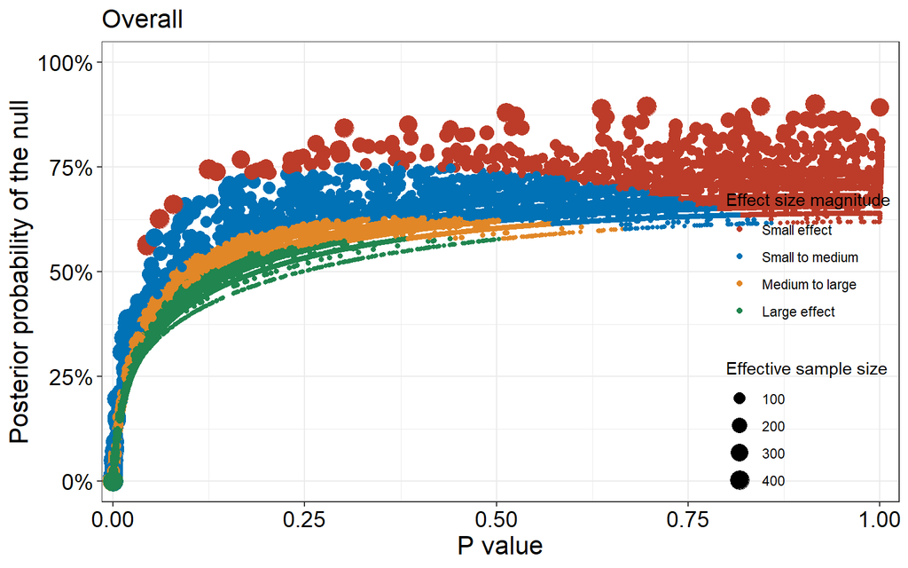

```r
# add es interpretation
dat3 <- dat2 %>%
  mutate(es_stren = case_when(
    abs(d) <= 0.2 ~ "Small effect",
    0.2 < abs(d) & abs(d) <= 0.5 ~ "Small to medium",
    0.5 < abs(d) & abs(d) <= 0.8 ~ "Medium to large",
    abs(d) > 0.2 ~ "Large effect"
  ))
dat3$es_stren <- as.factor(dat3$es_stren)
dat3$es_stren <- factor(dat3$es_stren, levels = c("Small effect", "Small to medium", "Medium to large", "Large effect"))

# overall
p1 <- filter(dat3, n < 500) %>%
  ggplot() +
  geom_point(aes(x = p, y = 1 - bf_post, size = n, color = es_stren)) +
  scale_y_continuous(limits = c(0,1), breaks = seq(0, 1, by = 0.25), labels = scales::percent_format(accuracy=1)) +
  scale_x_continuous(limits = c(0,1), breaks = seq(0, 1, by = 0.25), expand = expansion(mult = c(0.015, 0.025))) +
  scale_color_nejm() +
  theme_bw() +
  labs(x = "P value", y = "Posterior probability of the null", size = "Effective sample size", color = "Effect size magnitude", title = "Overall") +
  theme(axis.text = element_text(color = "black", size = 14),
        axis.title = element_text(color = "black", size = 16),
        plot.title = element_text(color = "black", size = 16),
        legend.position = c(1, 0), legend.justification = c(1, 0),
        legend.background = element_rect(colour = alpha("white", 0.0), fill = alpha("white", 0.0)),
        legend.key = element_rect(colour = alpha("white", 0.0), fill = alpha("white", 0.0)))

# No or weak evidence
p2 <- filter(dat3, bf_stren == "No or weak" & n < 500) %>%
  ggplot() +
  geom_point(aes(x = p, y = 1 - bf_post, size = n, color = es_stren)) +
  scale_y_continuous(limits = c(0,1), breaks = seq(0, 1, by = 0.25), labels = scales::percent_format(accuracy=1)) +
  scale_x_continuous(limits = c(0,1), breaks = seq(0, 1, by = 0.25), expand = expansion(mult = c(0.015, 0.025))) +
  scale_color_nejm() +
  theme_bw() +
  labs(x = "P value", y = "Posterior probability of the null", size = "Effective sample size", color = "Effect size magnitude", title = "No or weak evidence") +
  theme(axis.text = element_text(color = "black", size = 14),
        axis.title = element_text(color = "black", size = 16),
        plot.title = element_text(color = "black", size = 16),
        legend.position = c(1, 0), legend.justification = c(1, 0),
        legend.background = element_rect(colour = alpha("white", 0.0), fill = alpha("white", 0.0)),
        legend.key = element_rect(colour = alpha("white", 0.0), fill = alpha("white", 0.0)))

# Moderate or modest effect
p3 <- filter(dat3, bf_stren == "Moderate or modest" & n < 500) %>%
  ggplot() +
  geom_point(aes(x = p, y = 1 - bf_post, size = n, color = es_stren)) +
  scale_y_continuous(limits = c(0,0.3), breaks = seq(0, 0.3, by = 0.1), labels = scales::percent_format(accuracy=1)) +
  scale_x_continuous(limits = c(0,0.032), breaks = seq(0, 0.03, by = 0.01), expand = expansion(mult = c(0.015, 0.025))) +
  scale_color_nejm() +
  theme_bw() +
  labs(x = "P value", y = "Posterior probability of the null", size = "Effective sample size", color = "Effect size magnitude", title = "Moderate or modest evidence") +
  theme(axis.text = element_text(color = "black", size = 14),
        axis.title = element_text(color = "black", size = 16),
        plot.title = element_text(color = "black", size = 16),
        legend.position = c(1, 0), legend.justification = c(1, 0),
        legend.background = element_rect(colour = alpha("white", 0.0), fill = alpha("white", 0.0)),
        legend.key = element_rect(colour = alpha("white", 0.0), fill = alpha("white", 0.0)))



p4 <- filter(dat3, bf_stren == "Strong or very strong" & n < 500) %>%
  ggplot() +
  geom_point(aes(x = p, y = 1 - bf_post, size = n, color = es_stren)) +
  scale_y_continuous(limits = c(0,0.1), breaks = seq(0, 0.1, by = 0.025), labels = scales::percent_format(accuracy=1)) +
  scale_x_continuous(limits = c(0,0.0051), breaks = seq(0, 0.005, by = 0.001), expand = expansion(mult = c(0.015, 0.025))) +
  scale_color_nejm() +
  theme_bw() +
  labs(x = "P value", y = "Posterior probability of the null", size = "Effective sample size", color = "Effect size magnitude", title = "Strong or very strong evidence") +
  theme(axis.text = element_text(color = "black", size = 14),
        axis.title = element_text(color = "black", size = 16),
        plot.title = element_text(color = "black", size = 16),
        legend.position = c(1, 0), legend.justification = c(1, 0),
        legend.background = element_rect(colour = alpha("white", 0.0), fill = alpha("white", 0.0)),
        legend.key = element_rect(colour = alpha("white", 0.0), fill = alpha("white", 0.0)))


# save
#png(filename = "./fig 2.png", width = 11, height = 11, units = "in", type = "windows", res = 600)
#p1 + p2 + p3 + p4 + plot_layout(nrow = 2, ncol = 2 , tag_level = 'new') +
#  plot_annotation(tag_levels = list(c('A', "B", "C", "D"))) & theme(plot.tag = element_text(size = 14, face = "bold"))
#dev.off()
p1
```

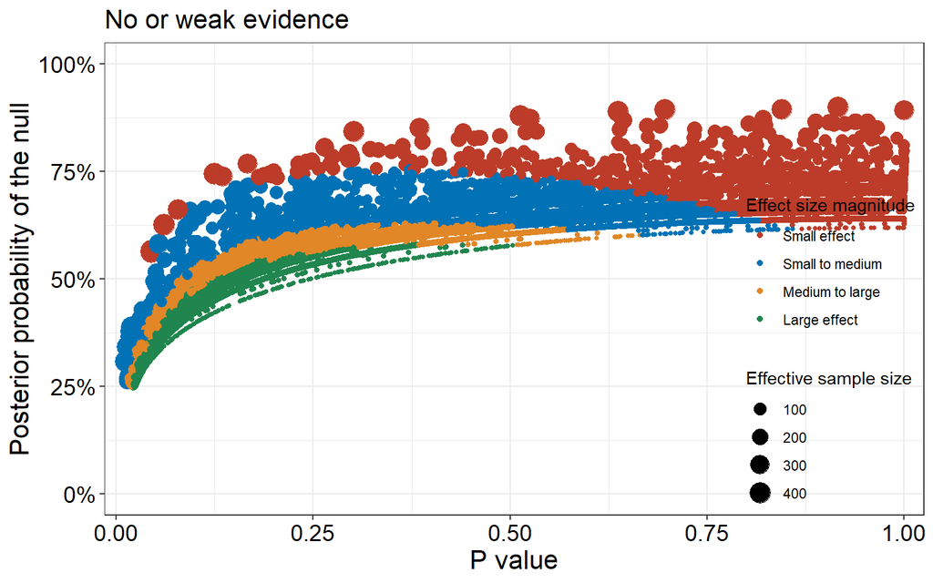

```r
p2
```

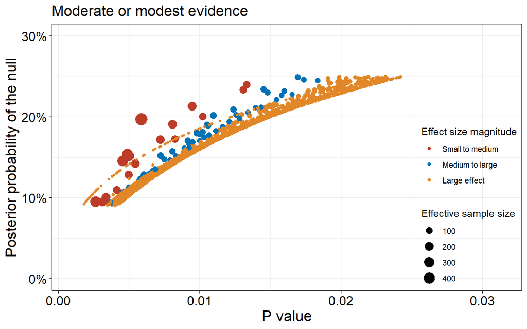

```r
p3
```

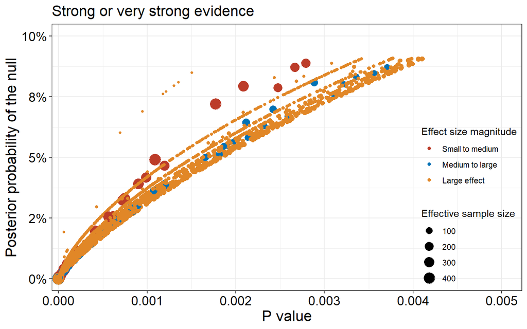

```r
p4
```

# Package information

```r
subset(data.frame(sessioninfo::package_info()), attached==TRUE, c(package, loadedversion))
```

```
##                 package loadedversion
## aplot             aplot         0.1.8
## BayesFactor BayesFactor    0.9.12-4.7
## boot               boot        1.3-28
## coda               coda        0.19-4
## cowplot         cowplot         1.1.1
## DescTools     DescTools       0.99.47
## dplyr             dplyr        1.0.10
## forcats         forcats         0.5.2
## ggExtra         ggExtra        0.10.0
## ggplot2         ggplot2         3.4.4
## ggsci             ggsci           2.9
## here               here         1.0.1
## irr                 irr        0.84.1
## lpSolve         lpSolve        5.6.15
## Matrix           Matrix         1.5-3
## metadat         metadat         1.2-0
## metafor         metafor        4.7-53
## numDeriv       numDeriv    2016.8-1.1
## paletteer     paletteer         1.5.0
## patchwork     patchwork         1.1.1
## purrr             purrr         0.3.4
## readr             readr         2.1.2
## stringr         stringr         1.5.0
## tibble           tibble         3.1.8
## tidyr             tidyr         1.2.1
## tidyverse     tidyverse         1.3.1
## viridis         viridis         0.6.2
## viridisLite viridisLite         0.4.0
## wesanderson wesanderson         0.3.6
## XICOR             XICOR         0.4.1
```